# Lab: Global plastic waste

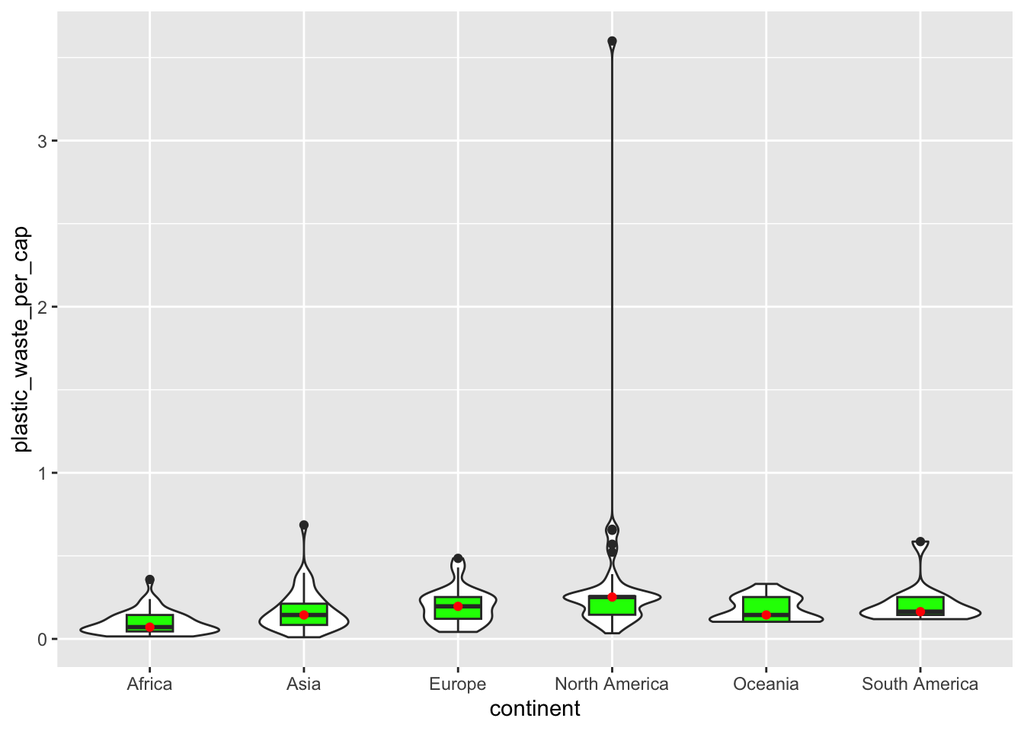

```r
ggplot(data = plastic_waste,
       mapping = aes(x = continent,
                     y = plastic_waste_per_cap)) +
  geom_violin()+
  geom_boxplot(width=.3, fill="green") +
  stat_summary(fun.y=median, geom="point", color="red")
```

4.1. Visualize the relationship between plastic waste per capita and mismanaged plastic waste per capita using a scatterplot. Describe the relationship.

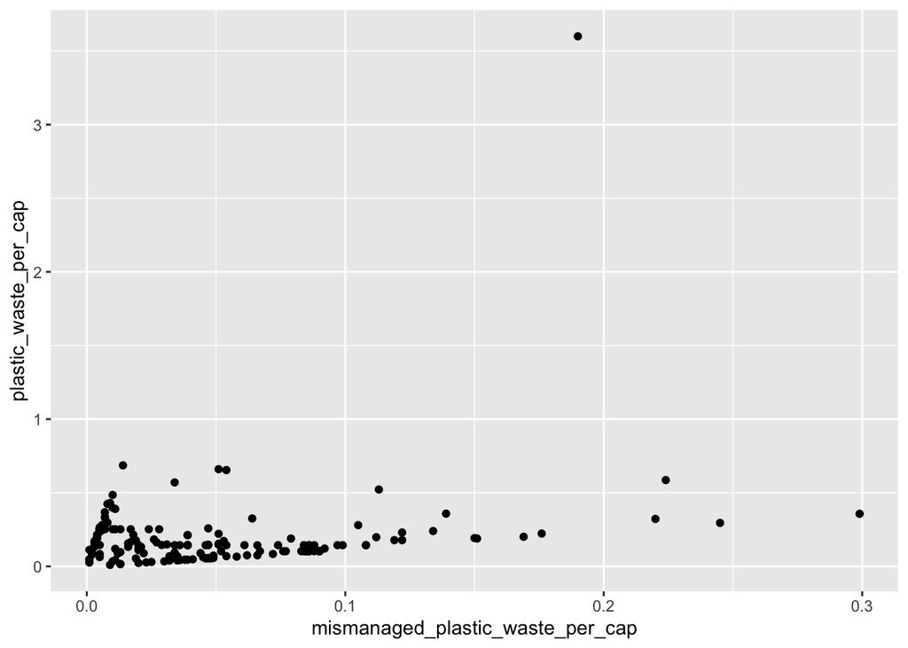

```r
ggplot(plastic_waste, aes(x=plastic_waste_per_cap, y=mismanaged_plastic_waste_per_cap)) +
  geom_point()+
  coord_flip()
```

4.2. Color the points in the scatterplot by continent. Does there seem to be any clear distinctions between continents with respect to how plastic waste per capita and mismanaged plastic waste per capita are associated?

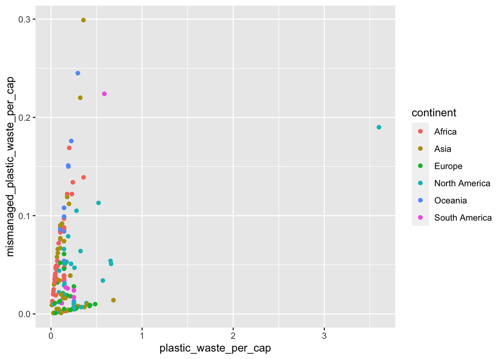

```r
ggplot(plastic_waste, aes(x=plastic_waste_per_cap, y=mismanaged_plastic_waste_per_cap, color=continent)) +
  geom_point()
```

4.3. Visualize the relationship between plastic waste per capita and total population as well as plastic waste per capita and coastal population. You will need to make two separate plots. Do either of these pairs of variables appear to be more strongly linearly associated?

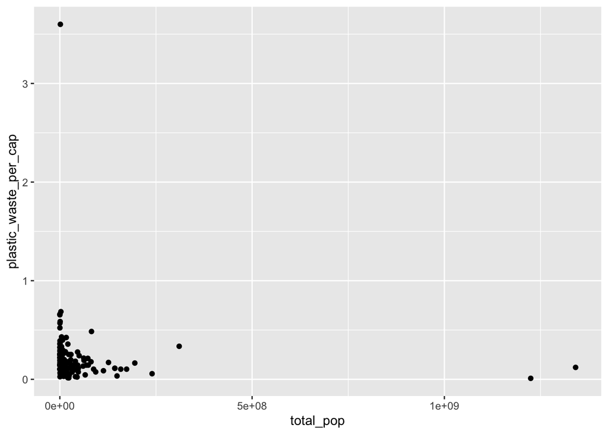

```r
ggplot(plastic_waste, aes(x=total_pop, y=plastic_waste_per_cap)) +
  geom_point()
```

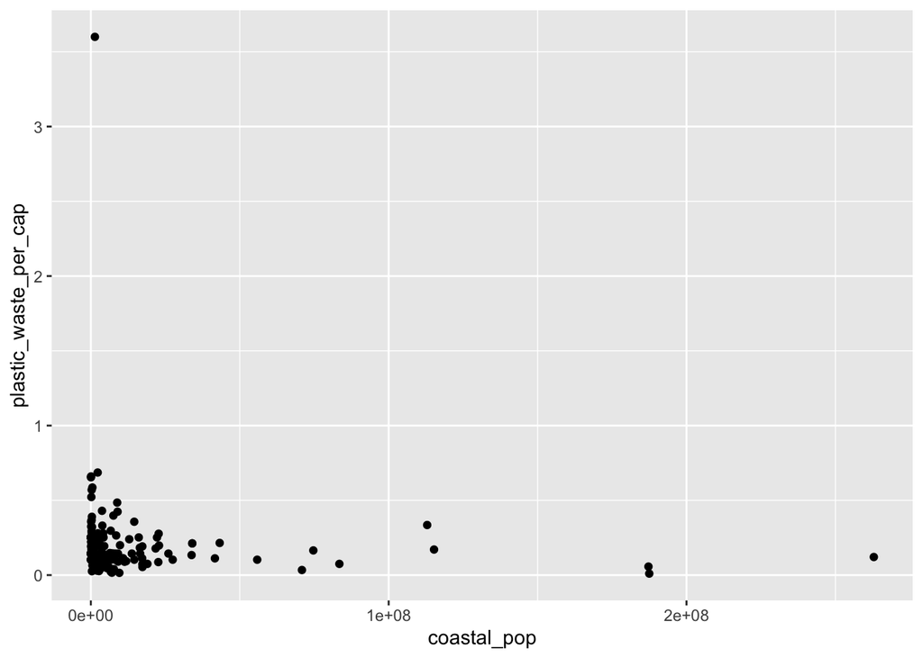

```r
ggplot(plastic_waste, aes(x=coastal_pop, y=plastic_waste_per_cap)) +
  geom_point()
```

## Wrapping up

5.1. Recreate the following plot, and interpret what you see in context of the data.

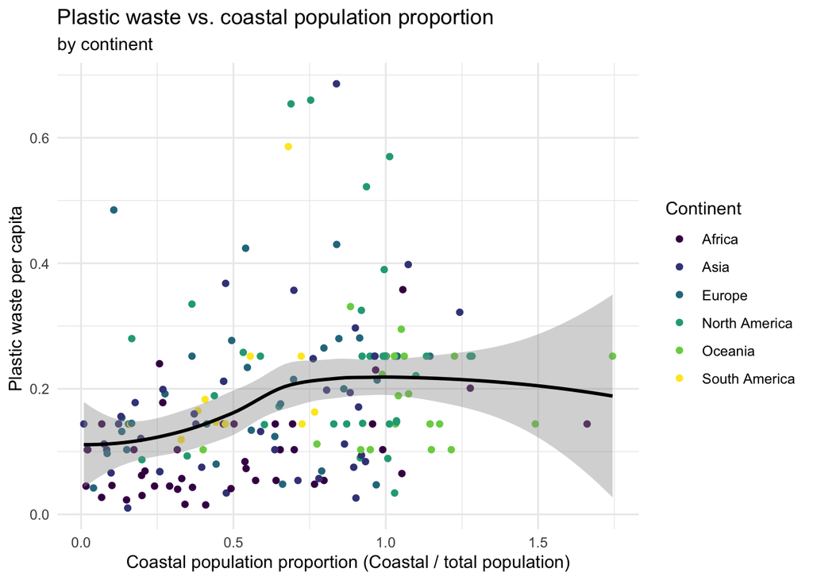

Helpful reference:http://www.sthda.com/english/wiki/ggplot2-themes-and-background-colors-the-3-elements